[O’Hara on GitHub](https://github.com/oharac)

# Plot map of impact and intensification quadrants

Compiled on Fri Jun 5 14:12:21 2020 by ohara

```r
library(raster)
library(sf)
source('https://raw.githubusercontent.com/oharac/src/master/R/common.R')

source(here('common_fxns.R'))

reload <- FALSE
```

# 1 Summary

Using impact maps and intensification maps, create a map dividing the ocean into categories with different ramifications for conservation.

- High impact, intensifying: top priority for reactive conservation
- Low impact, intensifying: top priority for proactive conservation
- High impact, deintensifying: (why priority? esp over high impact, stable stressors? perhaps these are areas ripe for reactive conservation to lock in gains at lower costs (financial or political)?)
- Low impact, deintensifying: (why priority, again over low impact stable stressors? as above, perhaps opportunities for lower cost protection)

For now this will be done at the stressor group level and cumulative level, at both a percent and count (and especially areas where both co-occur).

We will divide EEZ from ABNJ a la Selig et al 2014; this is not an issue in terrestrial systems (no ABNJ, though I suppose disputed regions).

# 2 Methods

## 2.1 Gather the necessary maps and reclassify

High and low impact will be represented by the cells with the top 10% and bottom 10% of proportional species impact (Selig et al use 10% for impact high/low). Note, this will be done after removing “special cases” of zero:

- zeroes due to absence of species, therefore zero impact. If stressors are present in these cells, future species assessments may locate species in this region, thus creating an impact where none is currently evident.
- zeroes due to absence of stressors, therefore zero impact. If species are present in these cells, future shifts in footprint of stressors may impinge on ranges in this location, creating an impact where none is currently evident.

The thresholds for high and low impacts will only look at cells with both species and stressors (i.e. not include special zeroes $\varnothing_{spp}$ or $\varnothing_{str}$)

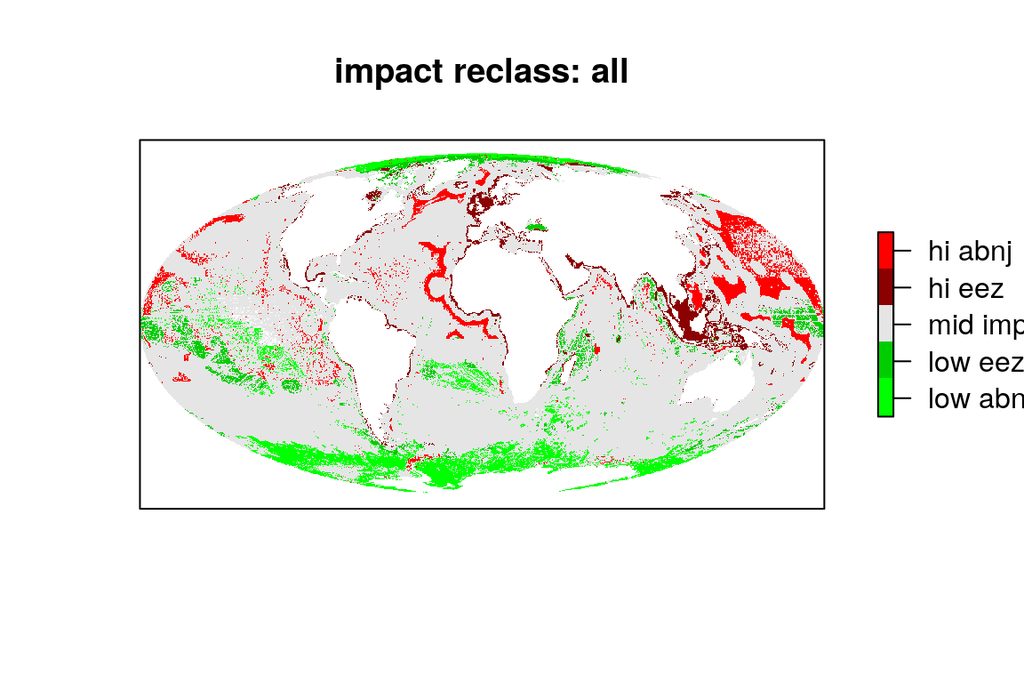

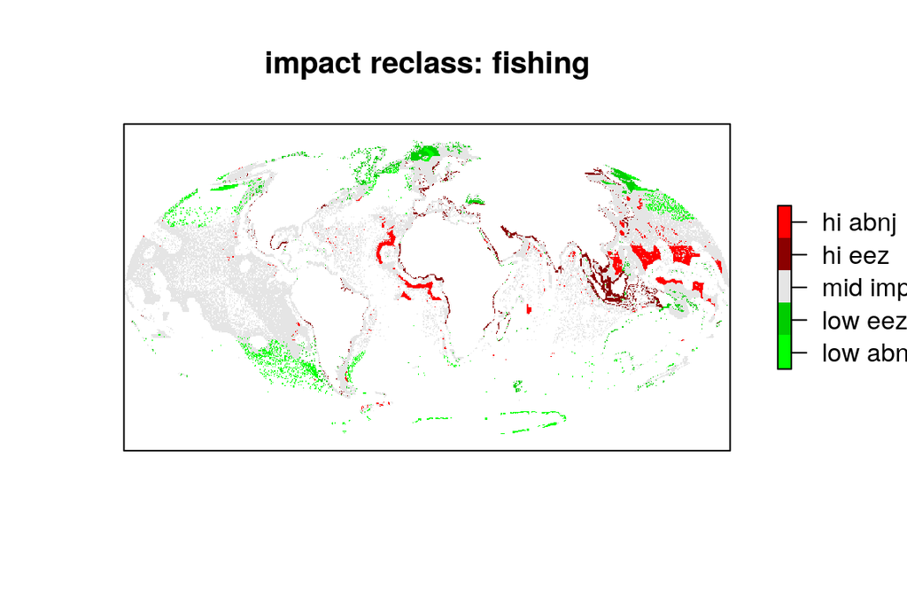

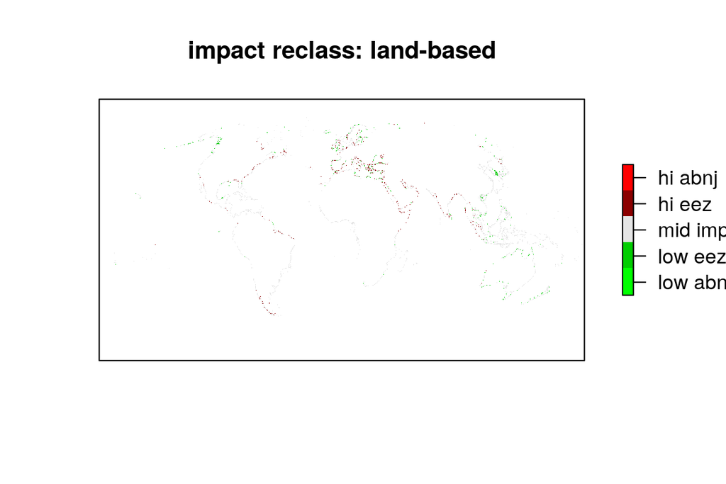

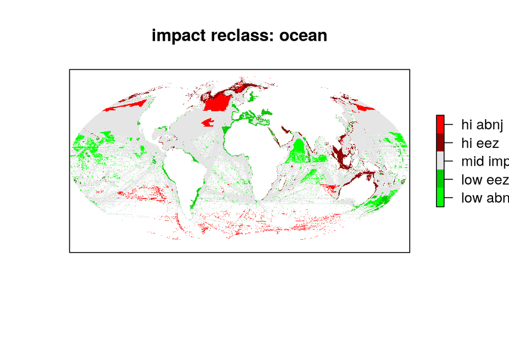

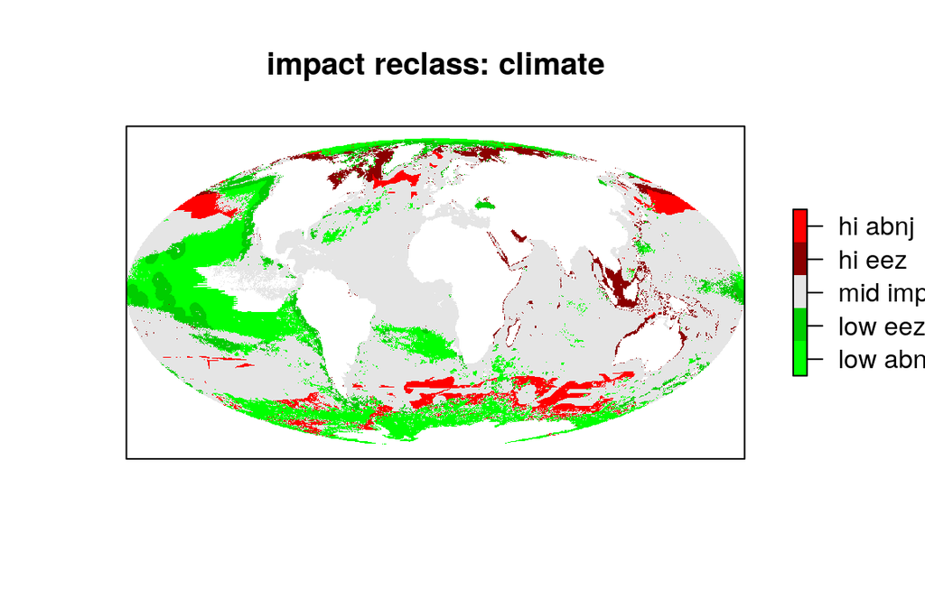

Intensification (points where an impacted species is affected by increasing stressor intensity) and deintensification will be combined by taking the difference (i.e. # of spp experiencing intensification - # of spp experiencing deintensification) and then normalizing by the number of spp present. The top 10% (and > 0) and bottom 10% (and < 0) will count as areas of high relative intensification and deintensification. These are reclassified into these categories:

$$\begin{align*}
intensification_{reclass} = \begin{cases}
+1 &\text{when high/pos net intensification}\\
-1 &\text{when low/neg net intensification}\\
0 &\text{when neutral intensification}\\
NA &\text{when no spp $\varnothing_{spp}$ or stressors present $\varnothing_{str}$}
\end{cases}
\end{align*}$$

Threshold for net intensification is based only on cells with both species and stressors (i.e. not include special zeroes $\varnothing_{spp}$ or $\varnothing_{str}$)

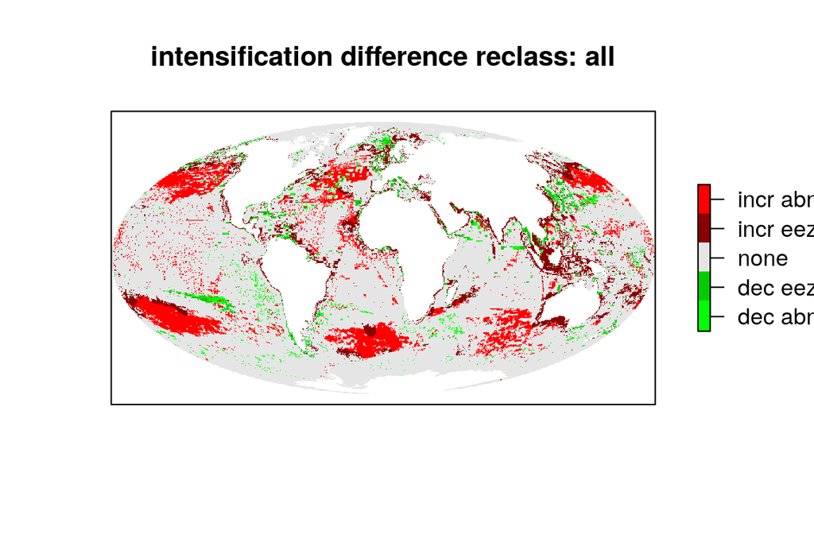

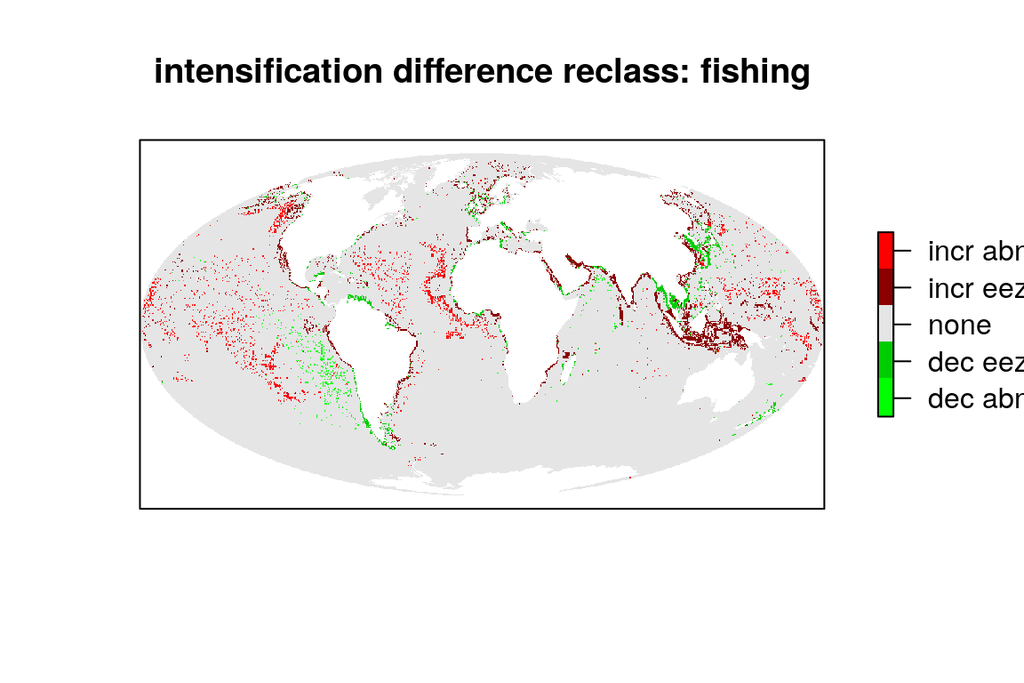

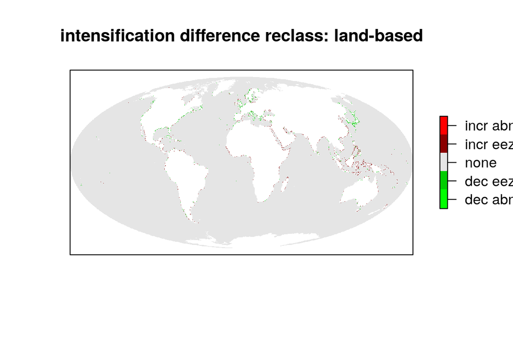

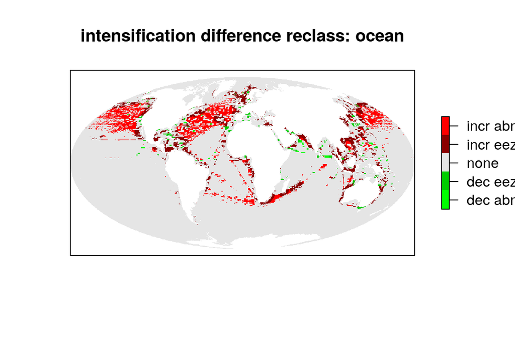

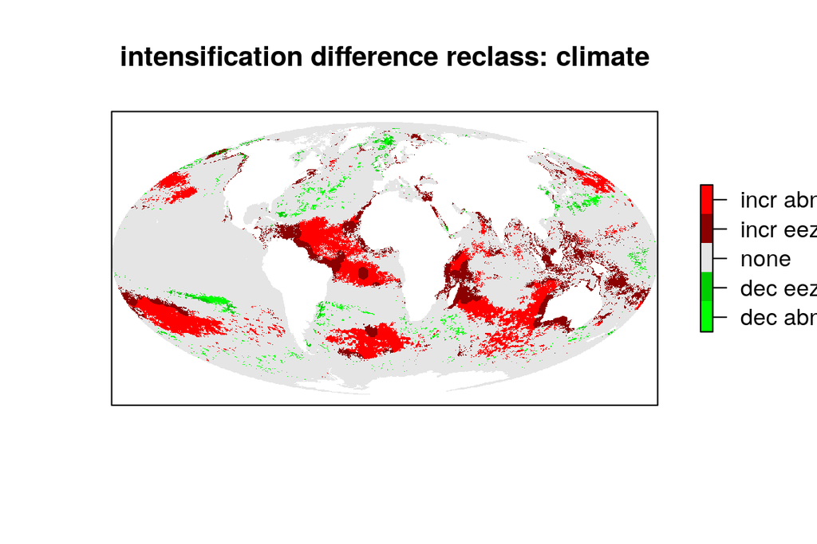

## 2.2 Combine the maps

Here we reclassify to four values (and zero for neutral):

$$\begin{align*}
value = \begin{cases}
+2 &\text{when high impact and intensifying}\\
+1 &\text{when high impact and de-intensifying}\\
-1 &\text{when low impact and intensifying}\\
-2 &\text{when low impact and de-intensifying}\\
NA &\text{when no spp $\varnothing_{spp}$ or stressors present $\varnothing_{str}$}
\end{cases}
\end{align*}$$

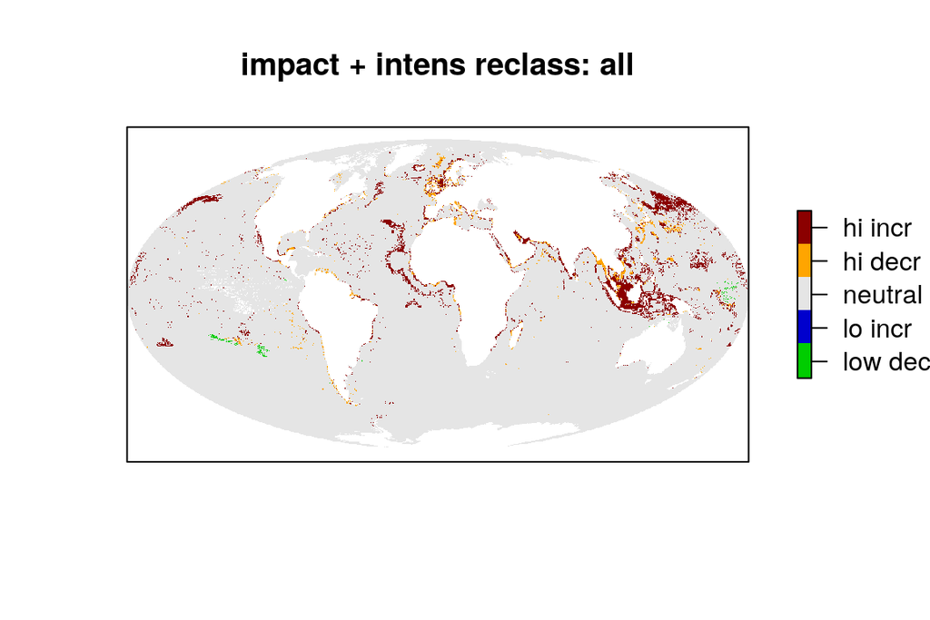

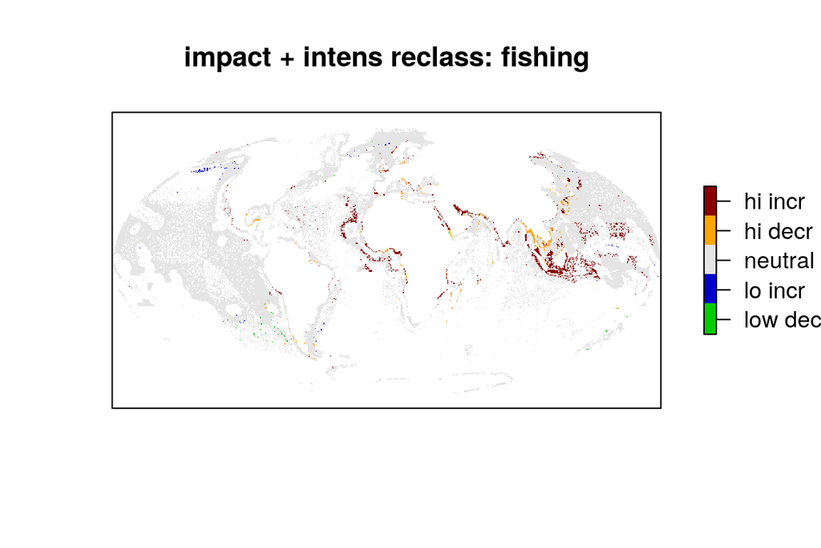

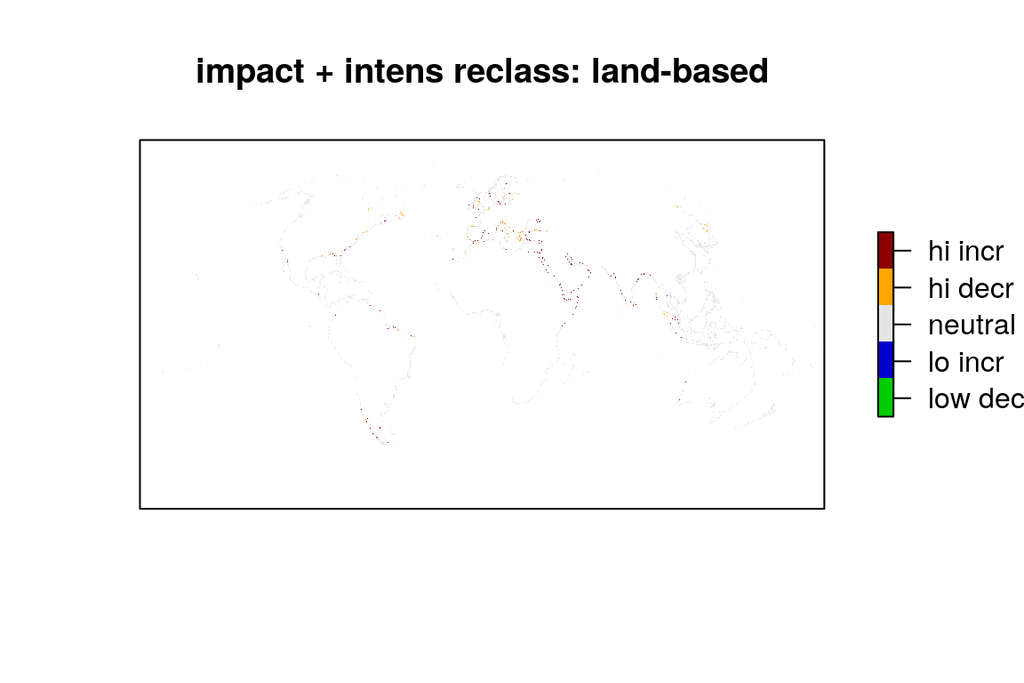

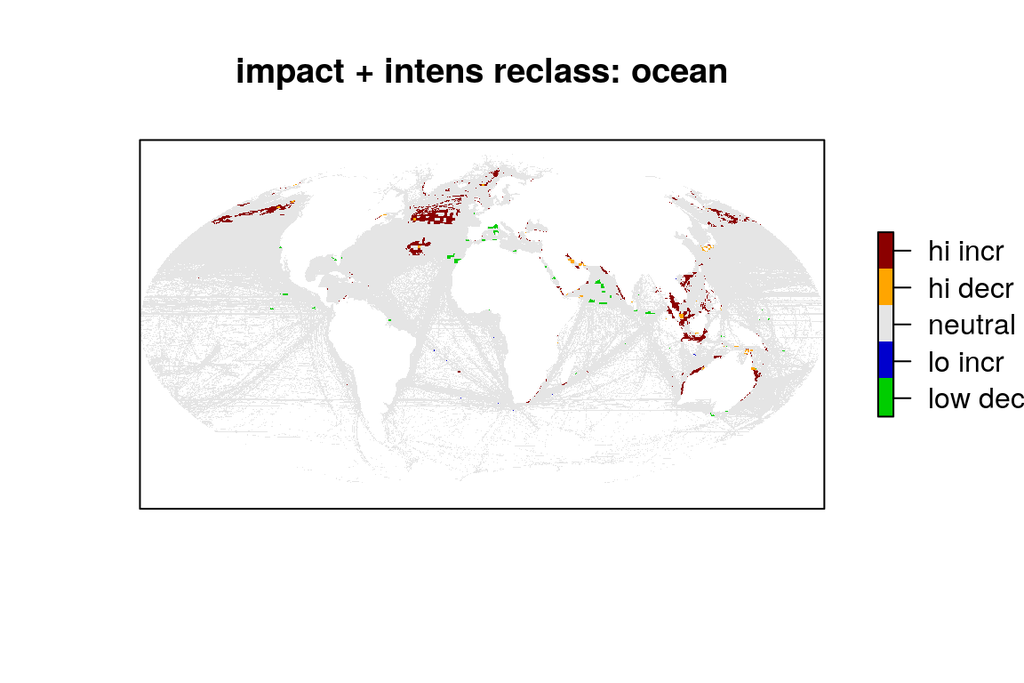

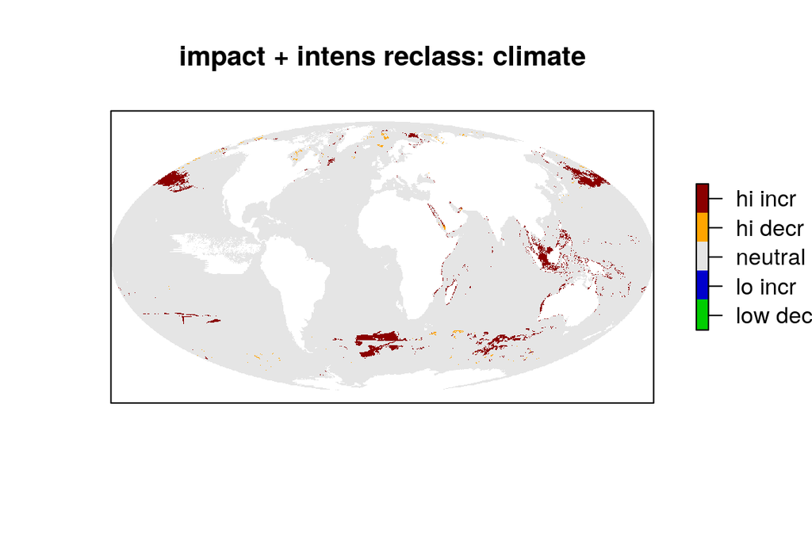